# cars_demo.R

neeraj

Wed Oct 8 01:07:23 2014

Get ggplot2 loaded in the environment

```r
require(ggplot2)
```

Get our cars data loaded from the included datasets.

```r
data(mpg)
```

Upon inspection, we find that there are only two timepoints for which these data were collected, 1999 and 2008. We can split our dataset into ‘old’ and ‘new’

```r
mpg_old <- subset(mpg, year == 1999)
mpg_new <- subset(mpg, year == 2008)
```

```r
p <- ggplot(mpg_old, aes(x=manufacturer, y=hwy))
```

Before we can draw anything, we need to plot something on top of the base-layer. We’ll tell ggplot to give us a boxplot with a blue fill color and it will use the x and y position set in the base layer.

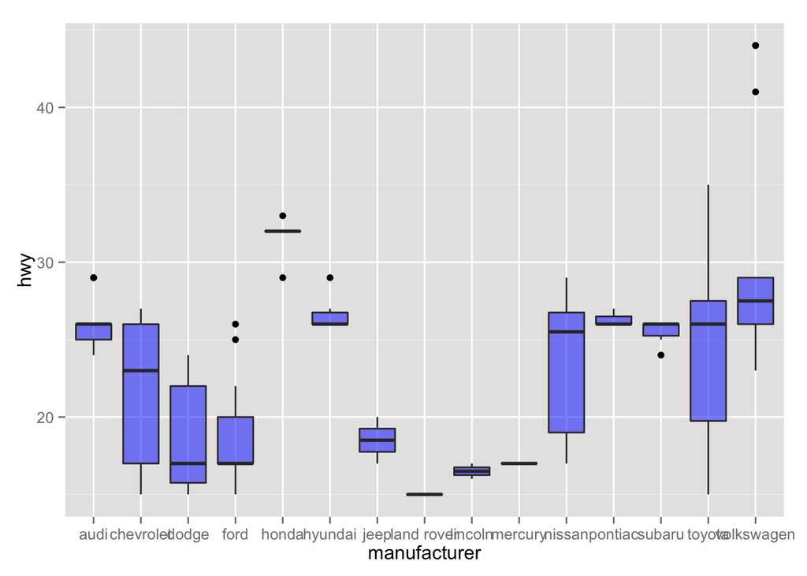

```r
p <- p + geom_boxplot(fill='blue', alpha=0.5)
print(p)
```

Next we can add the city data to the same plot, we’ll choose a red fill color for this layer, and point the y position to the city variable, and voila!

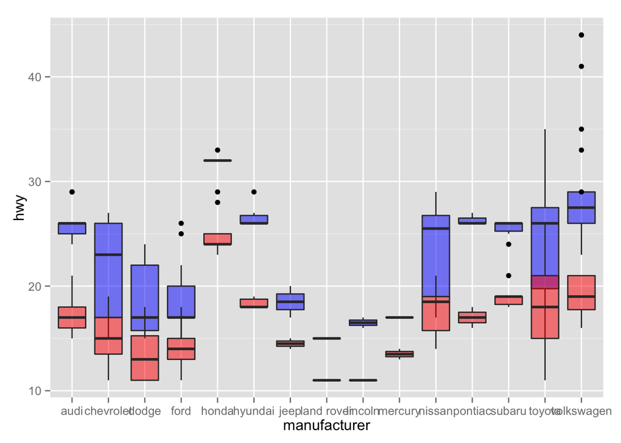

```r
plt3 <- p + geom_boxplot(aes(y=cty), fill='red', alpha=0.5)
print(plt3)
```

It’s kind of hard to read the labels of the manufacturers, isn’t it? Let’s fix that by editing the default theme to give us rotated labels. We’ll give the figure a title and fix the y axis label while we’re at it.

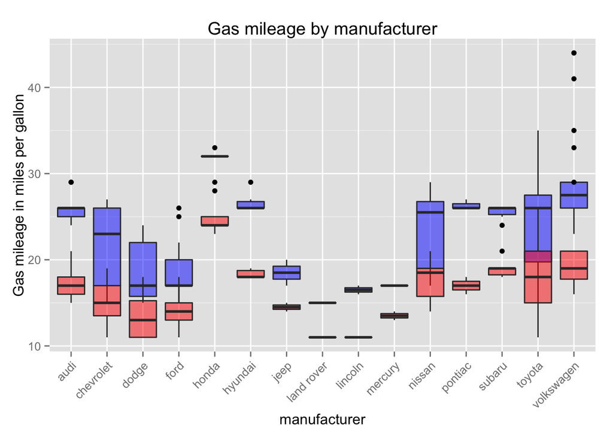

```r
plt4 <- plt3 + theme(axis.text.x = element_text(angle = 45, hjust = 1)) +
  ggtitle("Gas mileage by manufacturer") +
  ylab("Gas mileage in miles per gallon")
print(plt4)
```

Or we can flip the whole thing.

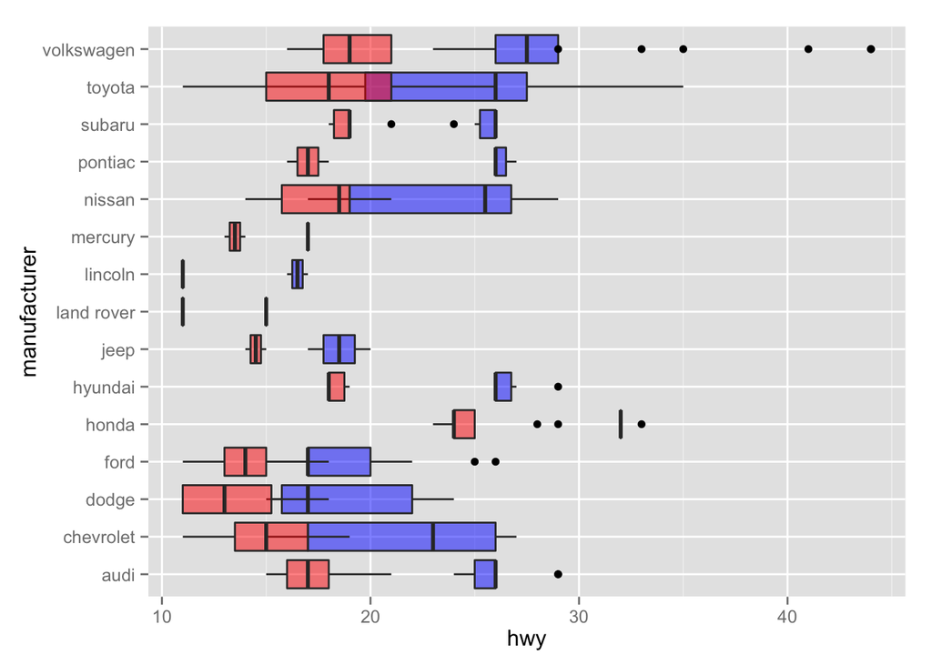

```r
plt5 <- plt3 + coord_flip()

print(plt5)
```

More to come